# ALRA-comparisons

Jacopo Umberto Verga

2023-04-24

# ALRA interactions

I run ALRA using all the healthy samples with NK cells divided in exhausted and resident. The results are:

```r
library(tidyverse)
library(VennDiagram)
library(stringr)
set.seed(1)
mm_interactions <- read_csv("all_interactions_defaults.csv", col_types = cols(...1 = col_skip()))
ht_interactions <- read_csv("all_healthy_interactions_default.csv", col_types = cols(...1 = col_skip()))


exh_mm = mm_interactions %>%
  filter(target == "NK exhausted")

res_mm = mm_interactions %>%
  filter(target == "NK resident")

exh_ht = ht_interactions %>%
  filter(target == "NK exhausted")

res_ht = ht_interactions %>%
  filter(target == "NK resident")
```

```r
variables = c("Total number of interactions", "Different Ligands", "Different Receptors")

mm = c(dim(mm_interactions)[1],
       length(unique(sort(mm_interactions$ligand.complex))),
       length(unique(sort(mm_interactions$receptor.complex))))

mm_nk_exh = c(dim(exh_mm)[1],
           length(unique(sort(exh_mm$ligand.complex))),
           length(unique(sort(exh_mm$receptor.complex))))

mm_nk_res = c(dim(res_mm)[1],
           length(unique(sort(res_mm$ligand.complex))),
           length(unique(sort(res_mm$receptor.complex))))

df_mm <- data.frame(variables, mm, mm_nk_exh, mm_nk_res) %>%
  mutate(nk_exh_ratio = round((mm_nk_exh/mm)*100,1)) %>%
  mutate(nk_res_ratio = round((mm_nk_res/mm)*100,1))



ht = c(dim(ht_interactions)[1],
       length(unique(sort(ht_interactions$ligand.complex))),
       length(unique(sort(ht_interactions$receptor.complex))))


ht_nk_exh = c(dim(exh_ht)[1],
           length(unique(sort(exh_ht$ligand.complex))),
           length(unique(sort(exh_ht$receptor.complex))))

ht_nk_res = c(dim(res_ht)[1],
           length(unique(sort(res_ht$ligand.complex))),
           length(unique(sort(res_ht$receptor.complex))))


df_ht <- data.frame(variables, ht, ht_nk_exh, ht_nk_res) %>%
  mutate(nk_exh_ratio = round((ht_nk_exh/ht)*100,1)) %>%
  mutate(nk_res_ratio = round((ht_nk_res/ht)*100,1))

df_mm
```

```
##                      variables    mm mm_nk_exh mm_nk_res nk_exh_ratio
## 1 Total number of interactions 21594      1288      1110          6.0
## 2            Different Ligands   274       120       100         43.8
## 3          Different Receptors   260        81        77         31.2
##   nk_res_ratio
## 1          5.1
## 2         36.5
## 3         29.6
```

```r
df_ht
```

```
##                      variables    ht ht_nk_exh ht_nk_res nk_exh_ratio
## 1 Total number of interactions 15346       750       579          4.9
## 2            Different Ligands   201        63        66         31.3
## 3          Different Receptors   199        56        55         28.1
##   nk_res_ratio
## 1          3.8
## 2         32.8
## 3         27.6
```

Lower number of interactions, ligands and receptors found in healthy samples. For both the condition NK cells take account of ~ 10% of the interactions. Each call state (resident or exhausted) take account of $\sim \frac{1}{3}$ ligands and receptors. Now have a deeper look in the ligands.

# Ligands

Check the ligands ective in MM and healthy cells, then with a focus on NK cells

```r
#mm_interactions["Condition"] = "MM"
#ht_interactions["Condition"] = "Healthy"
#all_interactions = rbind(mm_interactions, ht_interactions)
mm_ligands = unique(sort(mm_interactions$ligand.complex))
ht_ligands = unique(sort(ht_interactions$ligand.complex))

grid.newpage()
venn_object <- venn.diagram(
        x = list(mm_ligands, ht_ligands),
        category.names = c("MM", "Healthy"),
        print.mode=c("raw","percent"),
        fill = c("green", "yellow"),
        alpha=0.3,
        filename = NULL,
        disable.logging=TRUE
        )
```

[output not shown]

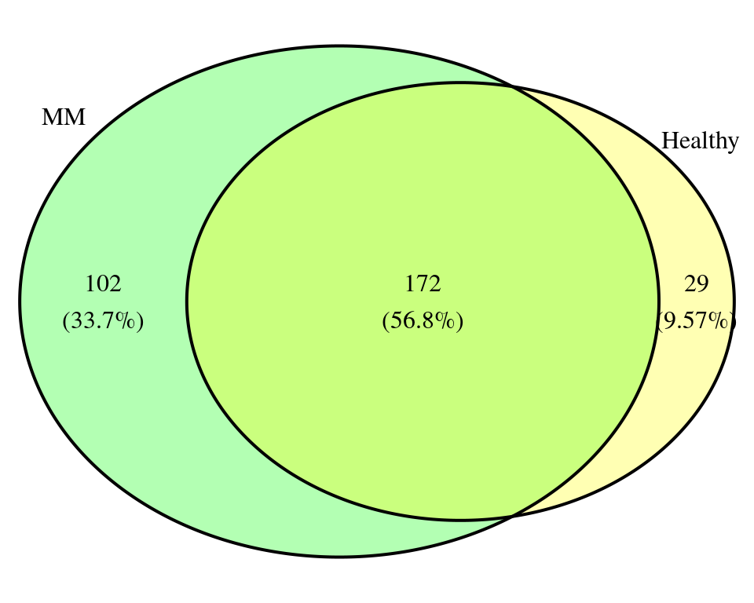

```r
grid.draw(venn_object)
```

56.8% of ligands are active in both healthy and MM samples, what about the ligands in NK cells?

```r
mm_nk = mm_interactions %>%
  filter(target == "NK resident" | target == "NK exhausted")

mm_ligands = unique(sort(mm_nk$ligand.complex))


ht_nk = ht_interactions %>%
  filter(target == "NK resident" | target == "NK exhausted")

ht_ligands = unique(sort(ht_nk$ligand.complex))

grid.newpage()
venn_object <- venn.diagram(
        x = list(mm_ligands, ht_ligands),
        category.names = c("MM", "Healthy"),
        print.mode=c("raw","percent"),
        fill = c("green", "yellow"),
        alpha=0.3,
        filename = NULL,
        disable.logging=TRUE
        )
```

[output not shown]

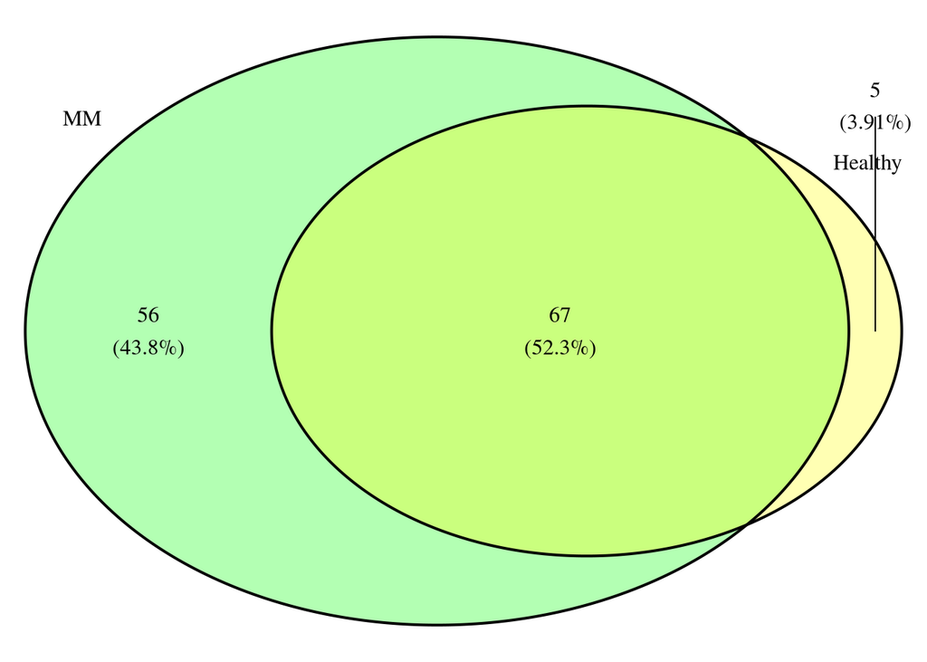

```r
grid.draw(venn_object)
```

52.3% of ligands shared by the two conditions. Interestingly MM samples have 56 ligands uniquely active (43.8%)

```r
cat("Ligands active only in healthy NK cells:\n", setdiff(ht_ligands,mm_ligands), "\nLigands active only in MM NK cells (subset of 5):\n", sample(setdiff(mm_ligands,ht_ligands),5))
```

```
## Ligands active only in healthy NK cells:
##  CD34 IGF1 PTDSS1 TOR2A VIM
## Ligands active only in MM NK cells (subset of 5):
##  ARF6 LTB ACTR2 HSPA8 GZMA
```

### Healthy:

- CD34, expressed by HSCs & MPPS, binds SELL in resident and exhausted NK cells
- IGF1, expressed by Plasma cell, binds IGF2R in NK exhausted. [Promotes cytotoxic activity](https://www.nature.com/articles/ncomms2484)
- PTDSS1, expressed by Conventional dendritic cell 1, binds JMJD6 in resident NK cells
- TOR2A, expressed by Conventional dendritic cell 1, binds ATP5F1B in resident NK cells

### MM

- ARF6, expressed by NK and dendritic cells, bind SMAP1 of NK exhausted. [responds to FCG3A activation](https://www.sciencedirect.com/science/article/pii/S0006497120532825)
- LTB, expressed by many cells, binds TNFRSF1A of exhausted and resident NK cells
- ACTR2/HSPA8, expressed by many cells, binds ADRB2 of exhausted and resident NK cells. [ADRB2 deletion impair NK activity](https://www.ncbi.nlm.nih.gov/pmc/articles/PMC7144534/)
- GZMA, expressed by many cells, binds F2R of exhausted and resident NK cells. [GZMA/F2R/JAK2/STAT1 signaling promoted apoptosis](https://www.nature.com/articles/s41419-022-04654-7) of tumor cells:
  - apoptosis NK cells?

Now compare exhausted and resident cells between the conditions:

## Exhausted NK cells:

```r
mm_ligands = unique(sort(exh_mm$ligand.complex))

ht_ligands = unique(sort(exh_ht$ligand.complex))

grid.newpage()
venn_object <- venn.diagram(
        x = list(mm_ligands, ht_ligands),
        category.names = c("MM", "Healthy"),
        print.mode=c("raw","percent"),
        fill = c("green", "yellow"),
        alpha=0.3,
        filename = NULL,
        disable.logging=TRUE
        )
```

[output not shown]

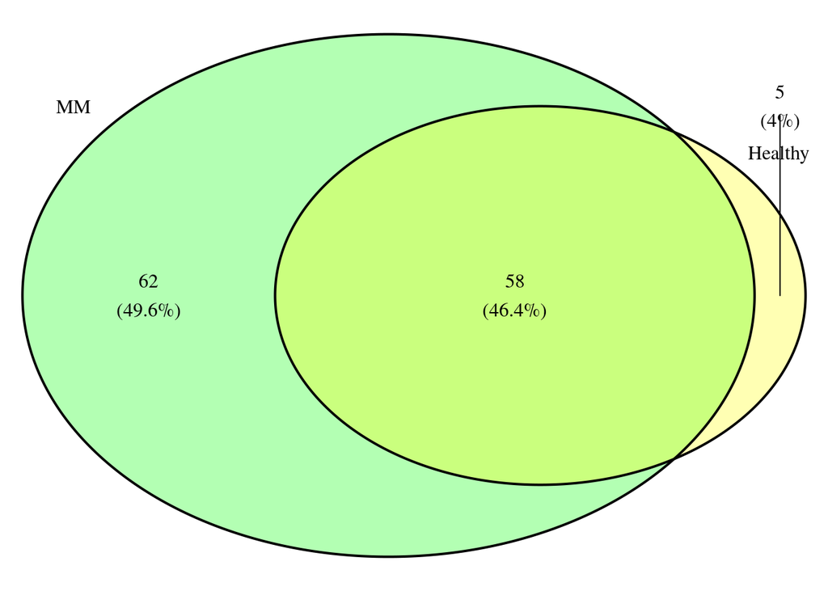

```r
grid.draw(venn_object)
```

A minority of ligands is active in healthy samples compared to MM exhausted NK cells. Also, Exhausted NK cells in MM have 62 active ligands that aren’t present in healthy samples. Only 5 ligands are uniquely active in healthy samples

```r
set.seed(1)
cat("Ligands active only in healthy exhausted NK cells:\n", setdiff(ht_ligands,mm_ligands), "\nLigands active only in MM exhausted NK cells (subset of 5):\n", sample(setdiff(mm_ligands,ht_ligands),5))
```

```
## Ligands active only in healthy exhausted NK cells:
##  AGTRAP CD34 IGF1 LILRB4 VIM
## Ligands active only in MM exhausted NK cells (subset of 5):
##  TF ADAM17 LGALS3 ACTR2 HLA-DRB1
```

## Resident NK cells:

```r
mm_ligands = unique(sort(res_mm$ligand.complex))

ht_ligands = unique(sort(res_ht$ligand.complex))

grid.newpage()
venn_object <- venn.diagram(
        x = list(mm_ligands, ht_ligands),
        category.names = c("MM", "Healthy"),
        print.mode=c("raw","percent"),
        fill = c("green", "yellow"),
        alpha=0.3,
        filename = NULL,
        disable.logging=TRUE
        )
```

[output not shown]

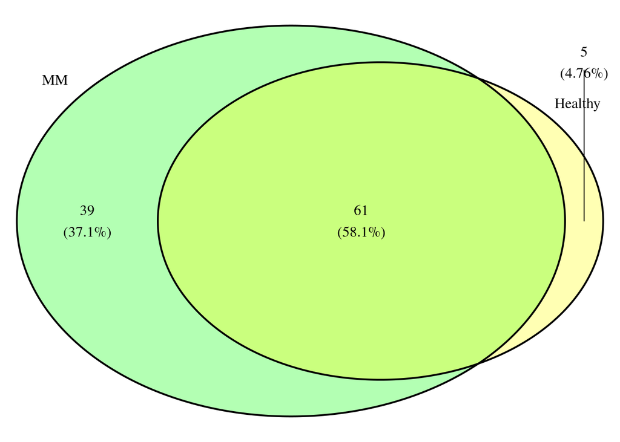

```r
grid.draw(venn_object)
```

```r
set.seed(1)
cat("Ligands active only in healthy NK cells:\n", setdiff(ht_ligands,mm_ligands), "\nLigands active only in MM NK cells (subset of 5):\n", sample(setdiff(mm_ligands,ht_ligands),5))
```

```
## Ligands active only in healthy NK cells:
##  CD34 PTDSS1 SPTAN1 TOR2A VIM
## Ligands active only in MM NK cells (subset of 5):
##  ARPC5 ACTR2 NPY HLA-F F11R
```

# Receptors

Check the receptors active in MM and healthy cells, then focus on NK cells

```r
#mm_interactions["Condition"] = "MM"
#ht_interactions["Condition"] = "Healthy"
#all_interactions = rbind(mm_interactions, ht_interactions)
mm_receptors = unique(sort(mm_interactions$receptor.complex))
ht_receptors = unique(sort(ht_interactions$receptor.complex))

grid.newpage()
venn_object <- venn.diagram(
        x = list(mm_receptors, ht_receptors),
        category.names = c("MM", "Healthy"),
        print.mode=c("raw","percent"),
        fill = c("green", "yellow"),
        alpha=0.3,
        filename = NULL,
        disable.logging=TRUE
        )
```

[output not shown]

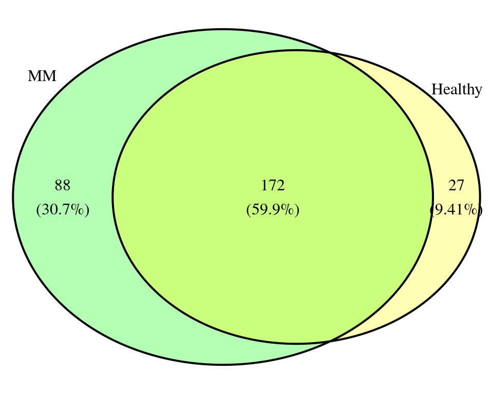

```r
grid.draw(venn_object)
```

59.9% receptors are active in both healthy and MM samples. MM samples have more active receptors compared to healthy samples. What about the receptors in NK cells?

```r
mm_receptors = unique(sort(mm_nk$receptor.complex))
ht_receptors = unique(sort(ht_nk$receptor.complex))

grid.newpage()
venn_object <- venn.diagram(
        x = list(mm_receptors, ht_receptors),
        category.names = c("MM", "Healthy"),
        print.mode=c("raw","percent"),
        fill = c("green", "yellow"),
        alpha=0.3,
        filename = NULL,
        disable.logging=TRUE
        )
```

[output not shown]

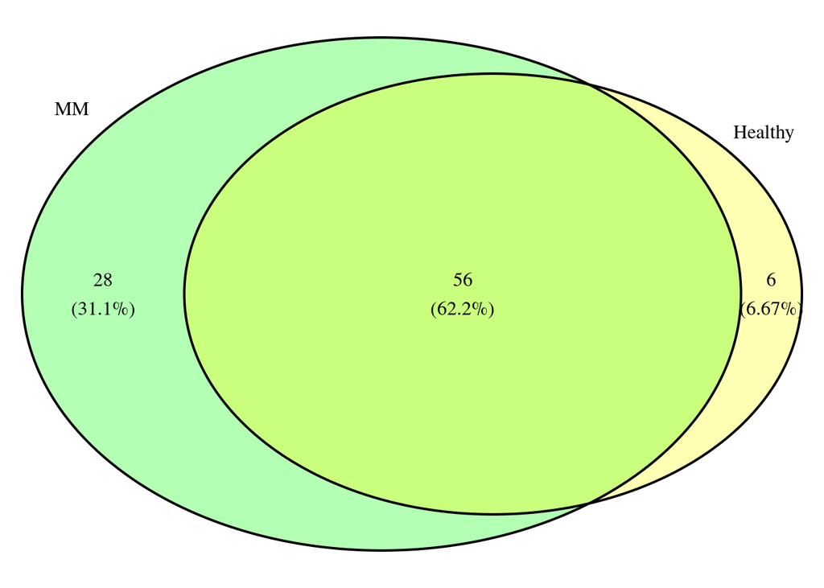

```r
grid.draw(venn_object)
```

62.2% receptors are shared by the two conditions. Only 6 receptors are activated uniquely in healthy samples while 28 (31.1%) are uniquely active in MM samples.

```r
set.seed(1)
cat("Ligands active only in healthy NK cells:\n", setdiff(ht_receptors,mm_receptors), "\nLigands active only in MM NK cells (subset of 6):\n", sample(setdiff(mm_receptors,ht_receptors),6))
```

```
## Ligands active only in healthy NK cells:
##  ATP5F1B CANX CD44_CD74 CD74 CD74_CXCR4 JMJD6
## Ligands active only in MM NK cells (subset of 6):
##  S1PR4 C1QBP CD8A ADRB2 BTN3A2 RAMP1
```

- CD44_CD74 CD74 CD74_CXCR4 complexes, inhibitory, are active only in healthy samples.

Now compare exhausted and resident cells between the conditions:

## Exhausted NK cells:

```r
mm_receptors = unique(sort(exh_mm$receptor.complex))

ht_receptors = unique(sort(exh_ht$receptor.complex))

grid.newpage()
venn_object <- venn.diagram(
        x = list(mm_receptors, ht_receptors),
        category.names = c("MM", "Healthy"),
        print.mode=c("raw","percent"),
        fill = c("green", "yellow"),
        alpha=0.3,
        filename = NULL,
        disable.logging=TRUE
        )
```

[output not shown]

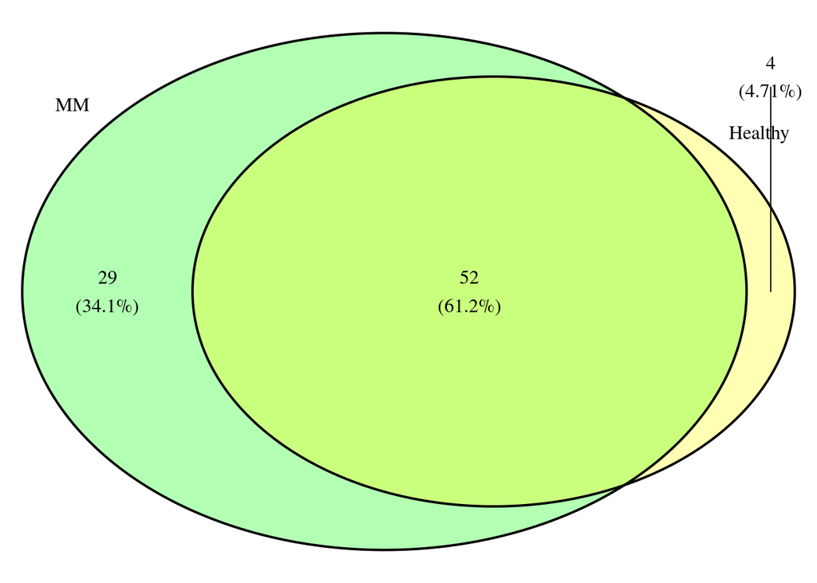

```r
grid.draw(venn_object)
```

61.2% of receptors are shared by exhausted NK cells between the conditions. As seen reviously, healthy samples have only 4 receptors active that aren’t present in MM samples. MM have 29 receptors uniquely activated.

```r
set.seed(1)
cat("Receptors active only in healthy exhausted NK cells:\n", setdiff(ht_receptors,mm_receptors), "\nReceptors active only in MM exhausted NK cells (subset of 4):\n", sample(setdiff(mm_receptors,ht_receptors),4))
```

```
## Receptors active only in healthy exhausted NK cells:
##  CANX CD74 LAIR1 RACK1
## Receptors active only in MM exhausted NK cells (subset of 4):
##  S1PR1 BTN3A3 CD81 ADRB2
```

## Resident

```r
mm_receptors = unique(sort(res_mm$receptor.complex))

ht_receptors = unique(sort(res_ht$receptor.complex))

grid.newpage()
venn_object <- venn.diagram(
        x = list(mm_receptors, ht_receptors),
        category.names = c("MM", "Healthy"),
        print.mode=c("raw","percent"),
        fill = c("green", "yellow"),
        alpha=0.3,
        filename = NULL,
        disable.logging=TRUE
        )
```

[output not shown]

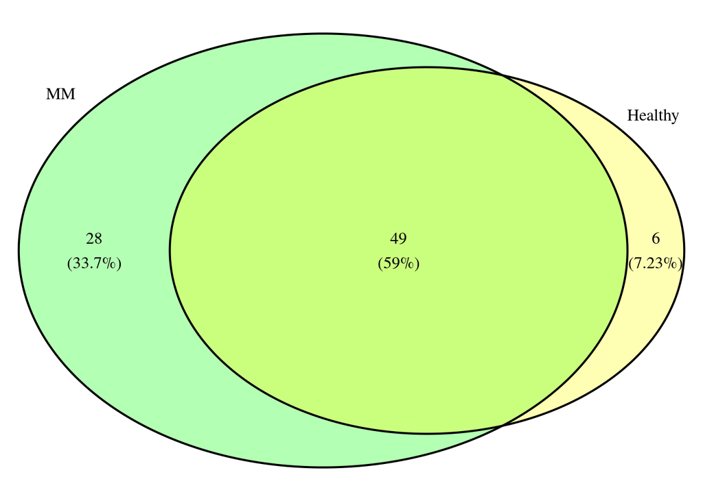

```r
grid.draw(venn_object)
```

Still 59% of shared receptors in resident NK cells. Healthy samples have 6 unique receptors:

```r
set.seed(1)
cat("Receptors active only in healthy NK cells:\n", setdiff(ht_receptors,mm_receptors), "\nReceptors active only in MM NK cells (subset of 6):\n", sample(setdiff(mm_receptors,ht_receptors),6))
```

```
## Receptors active only in healthy NK cells:
##  ATP5F1B CANX CD44_CD74 CD74_CXCR4 JMJD6 LAMP1
## Receptors active only in MM NK cells (subset of 6):
##  RAMP1 C1QBP CD81 ADRB2 BTN3A2 NMUR1
```

- [CD44/CD74/CXCR4](https://doi.org/10.3389/fimmu.2020.609948): inhibits NK citotoxycity, interesting found only in healthy cells.
- LAMP1, ligand FAM3C, important for NK cytotoxycity

## Number of interacting cells

Evaluate the proportion of celltypes that interacts with our NK cells in the two conditions:

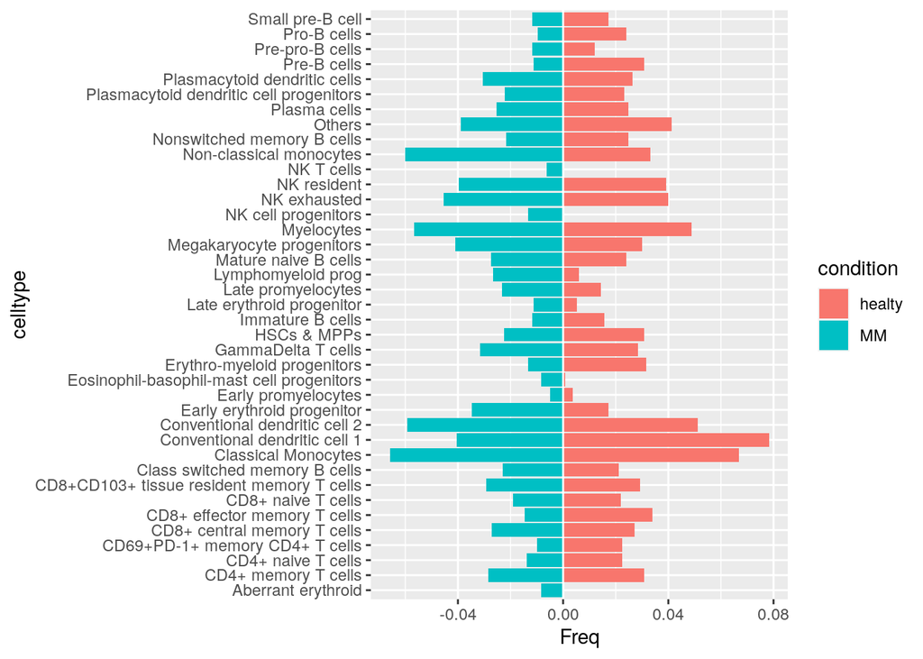

```r
mm_source <- as.data.frame(table(mm_nk$source)/sum(table(mm_nk$source))) %>%
  rename(celltype = "Var1") %>%
  mutate(condition="MM")
ht_source <- as.data.frame(table(ht_nk$source)/sum(table(ht_nk$source))) %>%
  rename(celltype = "Var1") %>%
  mutate(condition="healty")

source <- rbind(mm_source,ht_source)

source_plot <- source %>%
  mutate(
    Freq = ifelse(condition=="MM", Freq*(-1),
                        Freq*1))%>%
    ggplot(aes(x = celltype,y = Freq, fill=condition)) +
    geom_bar(stat = "identity") +
    coord_flip() +
  geom_hline(yintercept = 0, color="white")

source_plot
```

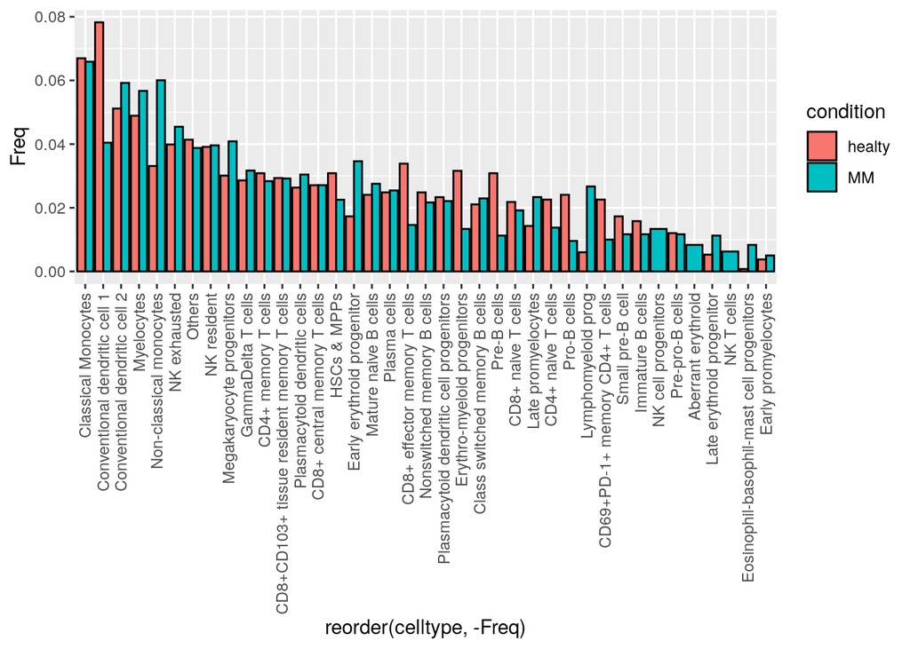

```r
source_dodge <- ggplot(source, aes(x=reorder(celltype,-Freq), y=Freq, fill=condition)) +
geom_bar(stat="identity", color="black", position=position_dodge())+
  theme(axis.text.x = element_text(angle = 90, vjust = 0.5, hjust=1))

source_dodge
```

Different proportions od interacting celtype were found between healthy and MM sampes: - Conventional dendritic cells 1 interact more with healthy NK cells than MM - Non-classical monocytes and Megakaryocyte progenitors interact more with MM than healthy NK cells

## Exhausted NK cells:

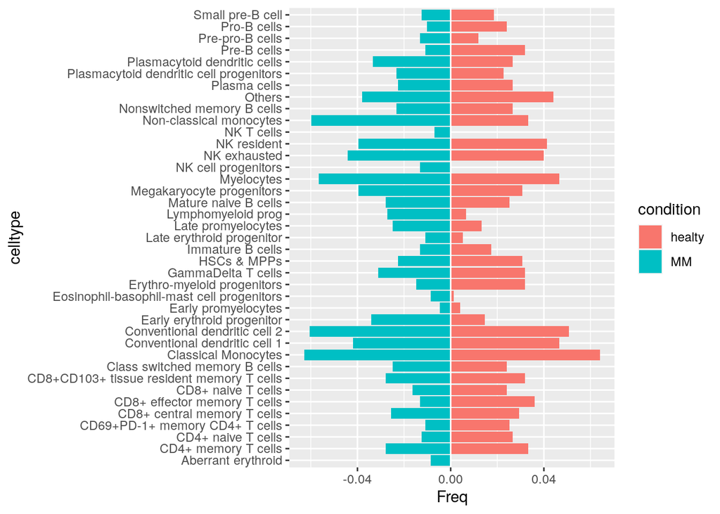

```r
mm_source <- as.data.frame(table(exh_mm$source)/sum(table(exh_mm$source))) %>%
  rename(celltype = "Var1") %>%
  mutate(condition="MM")
ht_source <- as.data.frame(table(exh_ht$source)/sum(table(exh_ht$source))) %>%
  rename(celltype = "Var1") %>%
  mutate(condition="healty")

source <- rbind(mm_source,ht_source)

source_plot <- source %>%
  mutate(
    Freq = ifelse(condition=="MM", Freq*(-1),
                        Freq*1))%>%
    ggplot(aes(x = celltype,y = Freq, fill=condition)) +
    geom_bar(stat = "identity") +
    coord_flip() +
  geom_hline(yintercept = 0, color="white")

source_plot
```

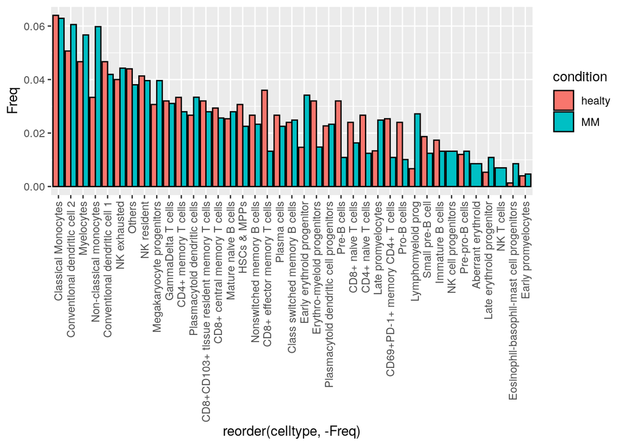

```r
source_dodge <- ggplot(source, aes(x=reorder(celltype,-Freq), y=Freq, fill=condition)) +
geom_bar(stat="identity", color="black", position=position_dodge())+
  theme(axis.text.x = element_text(angle = 90, vjust = 0.5, hjust=1))

source_dodge
```

Some differences in the cells that interact with exhausted NK cells between MM and healthy can be highlighted: - proportionally, Conventional dendritic cell 2, myelocytes, non-classical monocytes, early erythroid progenitors, lymphomyeloid progenitor interacts more with exhausted cells in MM than in healthy samples - proportionally, CD8+ em T cell, erythro-myeloid progenitors, pre-B cells, CD8+ naive T cells, CD4+ nave T cells, CD69+PD-1+ memory CD4+ T cells, Pro-B cells interacts more with exhausted cells in healthy than in MM samples - More adaptive-immune cells interactions in healthy than MM

## Resident NK cells:

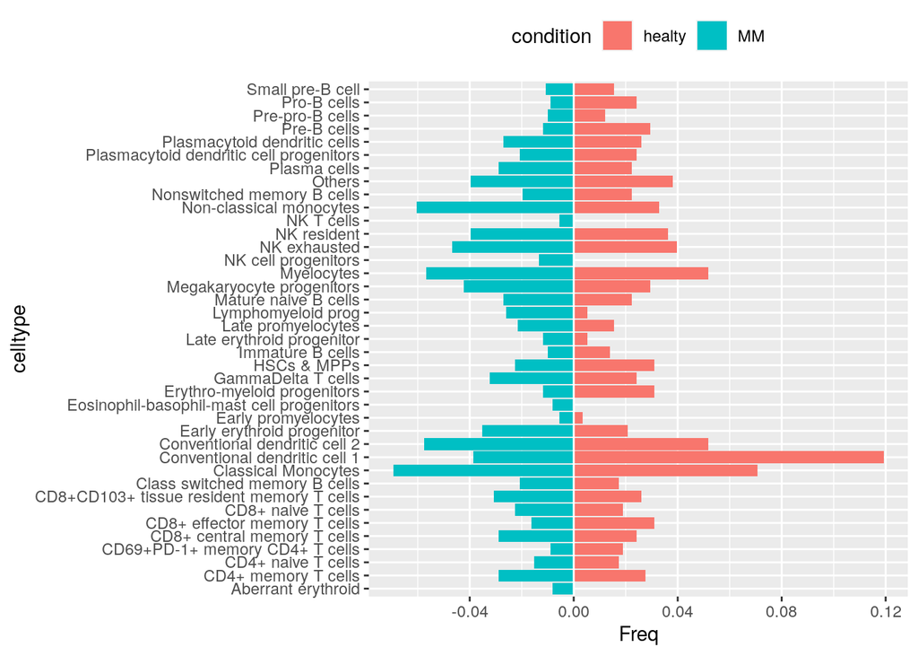

```r
mm_source <- as.data.frame(table(res_mm$source)/sum(table(res_mm$source))) %>%
  rename(celltype = "Var1") %>%
  mutate(condition="MM")
ht_source <- as.data.frame(table(res_ht$source)/sum(table(res_ht$source))) %>%
  rename(celltype = "Var1") %>%
  mutate(condition="healty")

source <- rbind(mm_source,ht_source)

source_plot <- source %>%
  mutate(
    Freq = ifelse(condition=="MM", Freq*(-1),
                        Freq*1))%>%
    ggplot(aes(x = celltype,y = Freq, fill=condition)) +
    geom_bar(stat = "identity") +
    coord_flip() +
  geom_hline(yintercept = 0, color="white") +
  theme(legend.position = "top")

source_plot
```

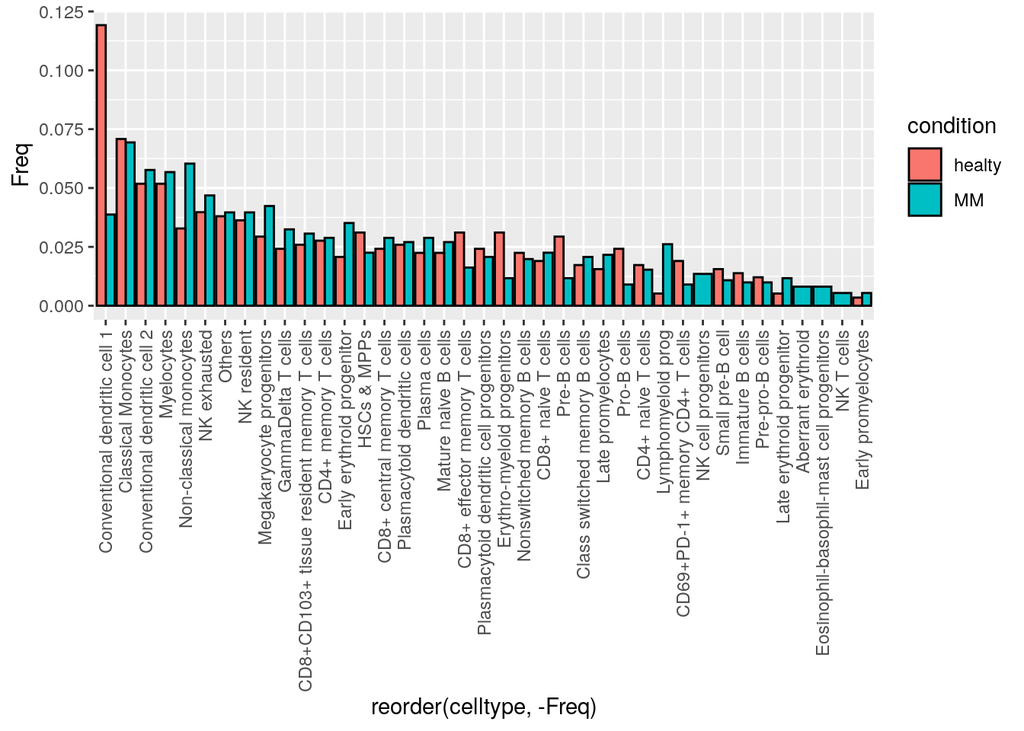

```r
source_dodge <- ggplot(source, aes(x=reorder(celltype,-Freq), y=Freq, fill=condition)) +
geom_bar(stat="identity", color="black", position=position_dodge())+
  theme(axis.text.x = element_text(angle = 90, vjust = 0.5, hjust=1))

source_dodge
```

# Number of interacting ligands

Now let’s check the receptors that receive most interactions

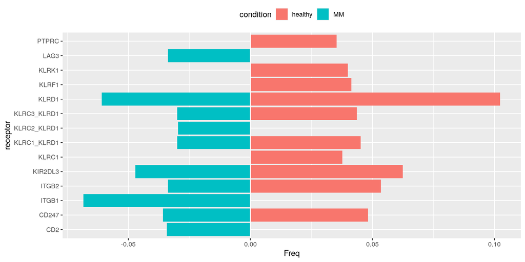

```r
mm_source <- as.data.frame(table(mm_nk$receptor.complex)/sum(table(mm_nk$receptor.complex))) %>%
  arrange(desc(Freq)) %>%
  rename(receptor = "Var1") %>%
  mutate(condition="MM")
ht_source <- as.data.frame(table(ht_nk$receptor.complex)/sum(table(ht_nk$receptor.complex))) %>%
  arrange(desc(Freq)) %>%
  rename(receptor = "Var1") %>%
  mutate(condition="healthy")

source <- rbind(mm_source[1:10,],ht_source[1:10,])

source_plot <- source %>%
  mutate(
    Freq = ifelse(condition=="MM", Freq*(-1),
                        Freq*1))%>%
    ggplot(aes(x = receptor,y = Freq, fill=condition)) +
    geom_bar(stat = "identity") +
    coord_flip() +
    geom_hline(yintercept = 0, color="white") +
  theme(legend.position = "top")

source_plot
```

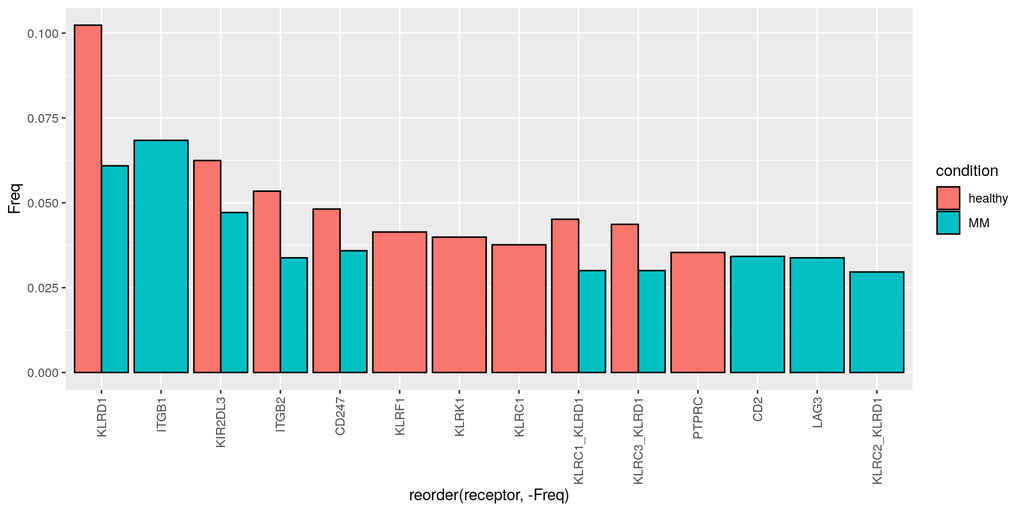

```r
source_dodge <- ggplot(source, aes(x=reorder(receptor,-Freq), y=Freq, fill=condition)) +
geom_bar(stat="identity", color="black", position=position_dodge())+
  theme(axis.text.x = element_text(angle = 90, vjust = 0.5, hjust=1))

source_dodge
```

## Exhausted NK cells:

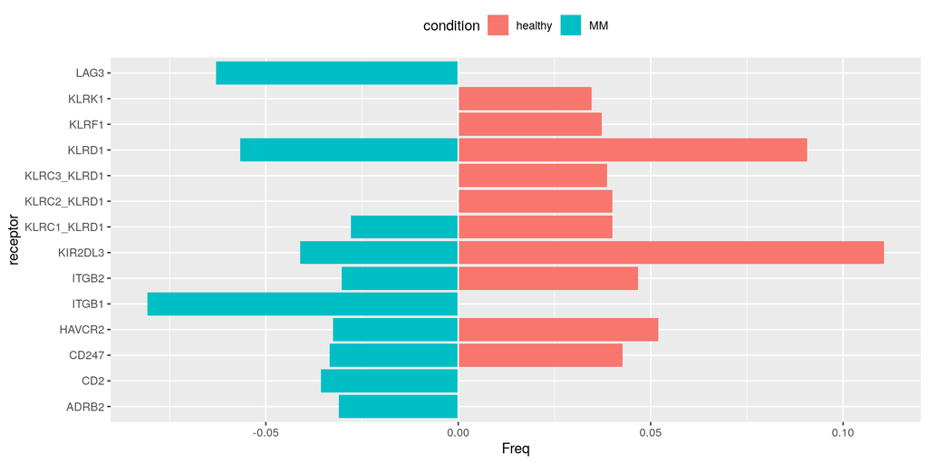

```r
mm_source <- as.data.frame(table(exh_mm$receptor.complex)/sum(table(exh_mm$receptor.complex))) %>%
  arrange(desc(Freq)) %>%
  rename(receptor = "Var1") %>%
  mutate(condition="MM")
ht_source <- as.data.frame(table(exh_ht$receptor.complex)/sum(table(exh_ht$receptor.complex))) %>%
  arrange(desc(Freq)) %>%
  rename(receptor = "Var1") %>%
  mutate(condition="healthy")

source <- rbind(mm_source[1:10,],ht_source[1:10,])

source_plot <- source %>%
  mutate(
    Freq = ifelse(condition=="MM", Freq*(-1),
                        Freq*1))%>%
    ggplot(aes(x = receptor,y = Freq, fill=condition)) +
    geom_bar(stat = "identity") +
    coord_flip() +
    geom_hline(yintercept = 0, color="white") +
  theme(legend.position = "top")

source_plot
```

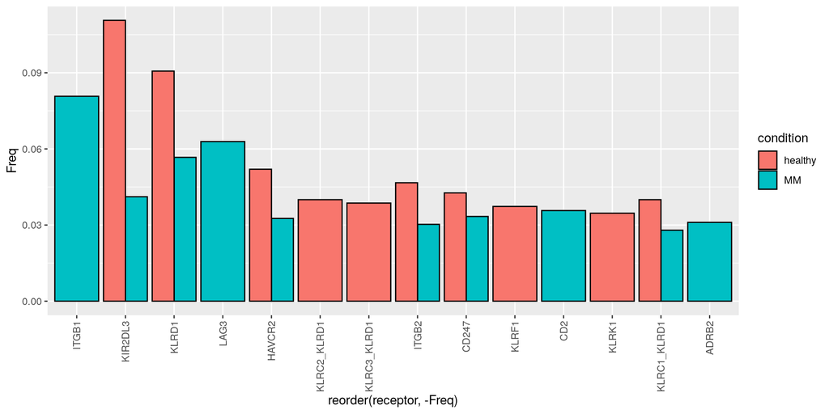

```r
source_dodge <- ggplot(source, aes(x=reorder(receptor,-Freq), y=Freq, fill=condition)) +
geom_bar(stat="identity", color="black", position=position_dodge())+
  theme(axis.text.x = element_text(angle = 90, vjust = 0.5, hjust=1))

source_dodge
```

## Resident NK cells:

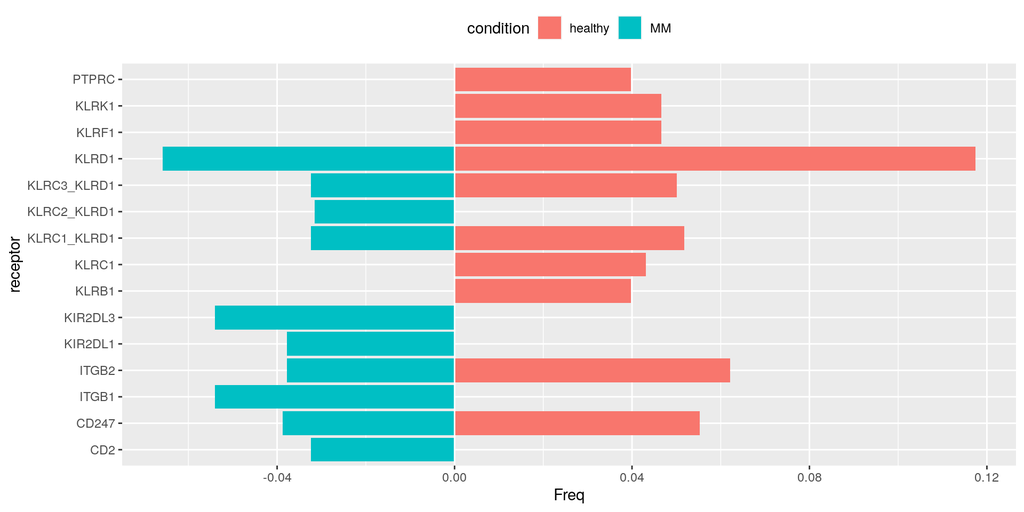

```r
mm_source <- as.data.frame(table(res_mm$receptor.complex)/sum(table(res_mm$receptor.complex))) %>%
  arrange(desc(Freq)) %>%
  rename(receptor = "Var1") %>%
  mutate(condition="MM")
ht_source <- as.data.frame(table(res_ht$receptor.complex)/sum(table(res_ht$receptor.complex))) %>%
  arrange(desc(Freq)) %>%
  rename(receptor = "Var1") %>%
  mutate(condition="healthy")

source <- rbind(mm_source[1:10,],ht_source[1:10,])

source_plot <- source %>%
  mutate(
    Freq = ifelse(condition=="MM", Freq*(-1),
                        Freq*1))%>%
    ggplot(aes(x = receptor,y = Freq, fill=condition)) +
    geom_bar(stat = "identity") +
    coord_flip() +
    geom_hline(yintercept = 0, color="white") +
  theme(legend.position = "top")

source_plot
```

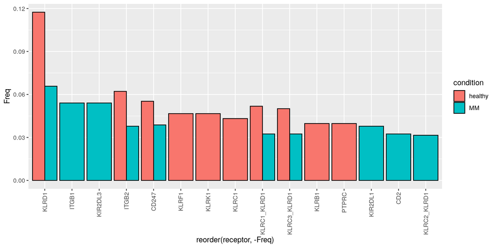

```r
source_dodge <- ggplot(source, aes(x=reorder(receptor,-Freq), y=Freq, fill=condition)) +
geom_bar(stat="identity", color="black", position=position_dodge())+
  theme(axis.text.x = element_text(angle = 90, vjust = 0.5, hjust=1))

source_dodge
```

# Immune checkpoint receptors:

Now have a look on the immune checkpoint receptors:

```r
ICR = c("KLRB1|KLRC1|KLRD1|KIR2DL1|KIR2DL3|KIR3DL1|KIR3DL2|KLRG1|KIR2DL4|TIGIT|LAG3|HAVCR2|BTLA|PDCD1|LILRB1|LILRB2|LILRB3|LILRB4|LILRB5|SIGLEC7|LAIR1|CEACAM1|PILRA|CD300A|CD96")

mm_ICR <- mm_nk %>%
  filter(grepl(ICR,receptor.complex)) %>%
  filter(!grepl("KLRC2|KLRC3", receptor.complex))

ht_ICR <- ht_nk %>%
  filter(grepl(ICR,receptor.complex)) %>%
  filter(!grepl("KLRC2|KLRC3", receptor.complex))


cat("MM cells:\nTotal number of ICR interactions: ",dim(mm_ICR)[1],"\nUnique Ligands: ",length(unique(sort(mm_ICR$ligand.complex))),"\nUnique Receptors: ",length(unique(sort(mm_ICR$receptor.complex))),"\n\n")
```

```
## MM cells:
## Total number of ICR interactions:  644
## Unique Ligands:  24
## Unique Receptors:  13
```

```r
cat("Healthy cells:\nTotal number of interactions: ",dim(ht_ICR)[1],"\nUnique Ligands: ",length(unique(sort(ht_ICR$ligand.complex))),"\nUnique Receptors: ",length(unique(sort(ht_ICR$receptor.complex))))
```

```
## Healthy cells:
## Total number of interactions:  417
## Unique Ligands:  11
## Unique Receptors:  7
```

Lower intreaction, receptors and ligands related to immune checkpoint are found in healthy samples compared to MM

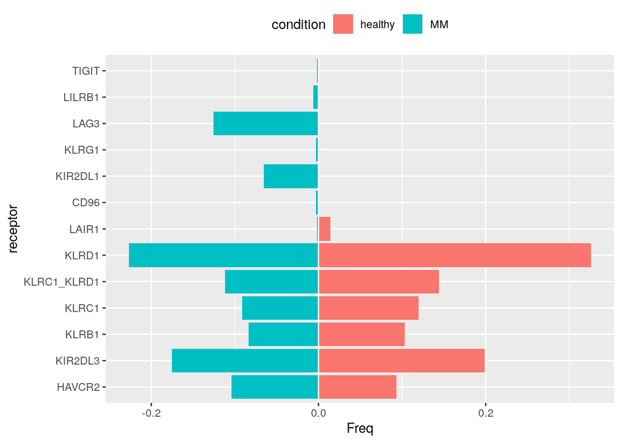

```r
exh_source <- as.data.frame(table(mm_ICR$receptor.complex)/sum(table(mm_ICR$receptor.complex))) %>%
  arrange(desc(Freq)) %>%
  rename(receptor = "Var1") %>%
  mutate(condition="MM")
res_source <- as.data.frame(table(ht_ICR$receptor.complex)/sum(table(ht_ICR$receptor.complex))) %>%
  arrange(desc(Freq)) %>%
  rename(receptor = "Var1") %>%
  mutate(condition="healthy")

source <- rbind(res_source,exh_source)

source_plot <- source %>%
  mutate(
    Freq = ifelse(condition=="MM", Freq*(-1),
                        Freq*1))%>%
    ggplot(aes(x = receptor,y = Freq, fill=condition)) +
    geom_bar(stat = "identity") +
    coord_flip() +
    geom_hline(yintercept = 0, color="white")+

  theme(legend.position = "top")

source_plot
```

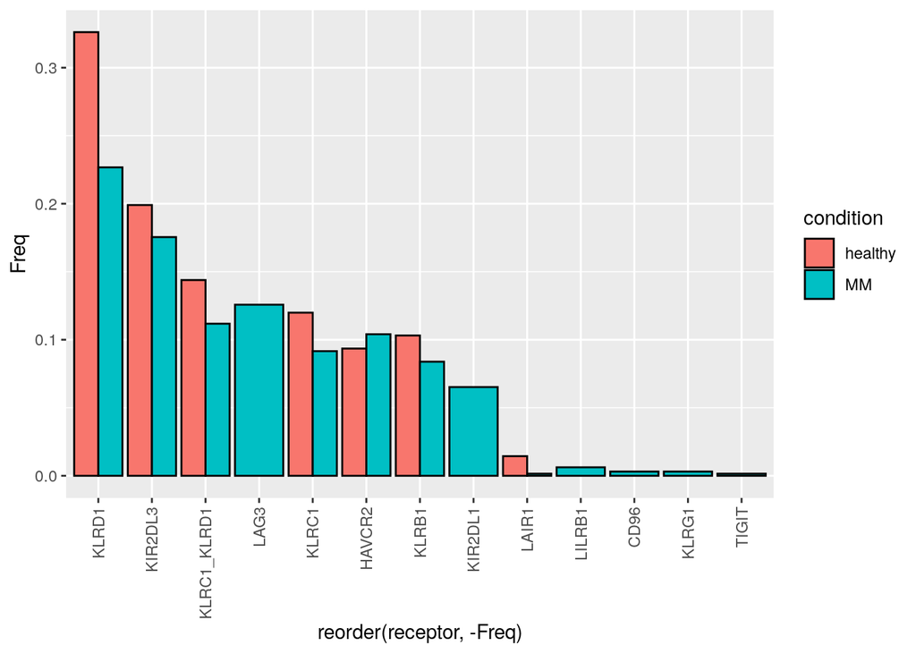

```r
source_dodge <- ggplot(source, aes(x=reorder(receptor,-Freq), y=Freq, fill=condition)) +
geom_bar(stat="identity", color="black", position=position_dodge())+
  theme(axis.text.x = element_text(angle = 90, vjust = 0.5, hjust=1))

source_dodge
```

- TIGIT, LAG3, LILRB1, KLRG1, KIR2DL1, CD96/TACTILE are activated only in MM
- LAIR1 receive proportionally more interactions in healthy cells (and in absolute numbers):

```r
cat("MM:", table(mm_ICR$receptor.complex[mm_ICR$receptor.complex == "LAIR1"]), "\nHealthy:", table(ht_ICR$receptor.complex[ht_ICR$receptor.complex == "LAIR1"]))
```

```
## MM: 1
## Healthy: 6
```

- HAVCR2/TIM3 acivated in both the conditions

Let’s focus on exhausted and resident nk cells

## Exhausted NK cells:

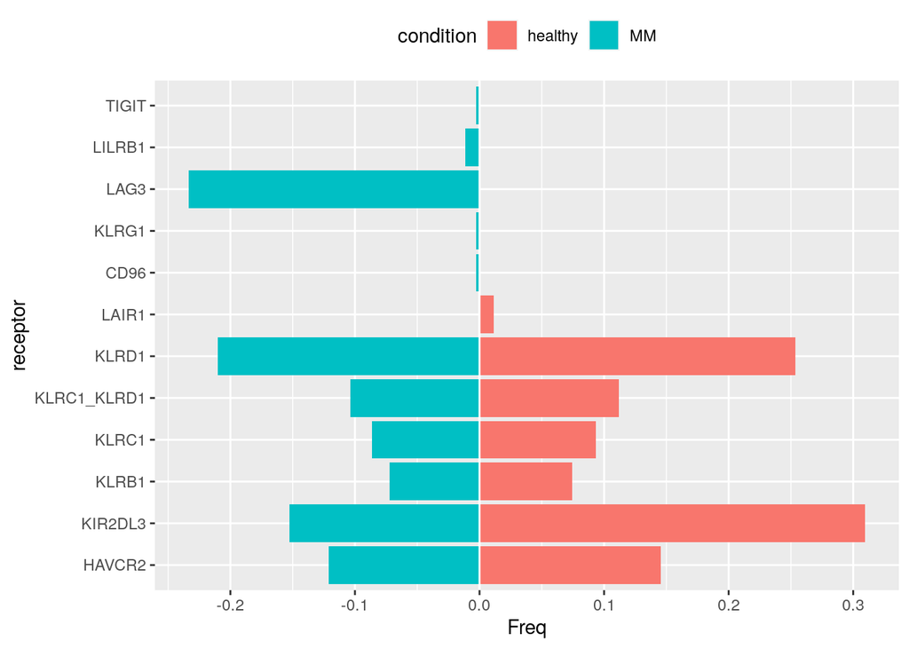

```r
mm_exh_ICR <- mm_ICR[mm_ICR$target == "NK exhausted", ]
ht_exh_ICR <- ht_ICR[ht_ICR$target == "NK exhausted", ]


exh_source <- as.data.frame(table(mm_exh_ICR$receptor.complex)/sum(table(mm_exh_ICR$receptor.complex))) %>%
  arrange(desc(Freq)) %>%
  rename(receptor = "Var1") %>%
  mutate(condition="MM")
res_source <- as.data.frame(table(ht_exh_ICR$receptor.complex)/sum(table(ht_exh_ICR$receptor.complex))) %>%
  arrange(desc(Freq)) %>%
  rename(receptor = "Var1") %>%
  mutate(condition="healthy")

source <- rbind(res_source,exh_source)

source_plot <- source %>%
  mutate(
    Freq = ifelse(condition=="MM", Freq*(-1),
                        Freq*1))%>%
    ggplot(aes(x = receptor,y = Freq, fill=condition)) +
    geom_bar(stat = "identity") +
    coord_flip() +
    geom_hline(yintercept = 0, color="white")+

  theme(legend.position = "top")

source_plot
```

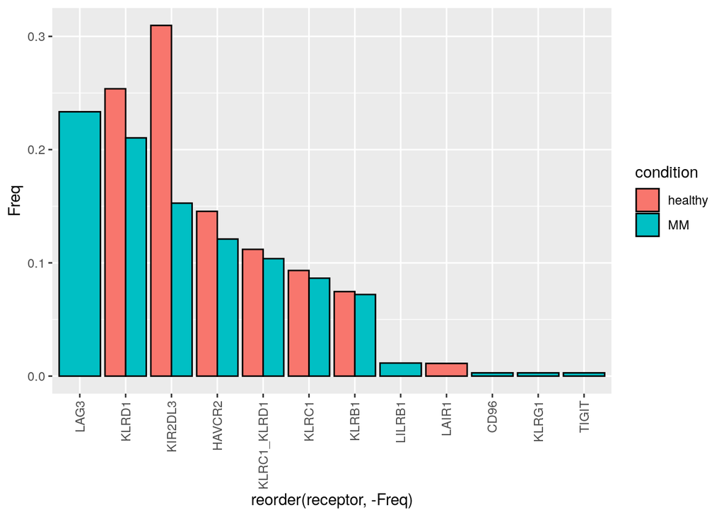

```r
source_dodge <- ggplot(source, aes(x=reorder(receptor,-Freq), y=Freq, fill=condition)) +
geom_bar(stat="identity", color="black", position=position_dodge())+
  theme(axis.text.x = element_text(angle = 90, vjust = 0.5, hjust=1))

source_dodge
```

- TIGIT, LILRB1, LAG3, KLRG1, CD96/TACTILE are activated only in MM
- LAIR1 activated only in healthy cells
- HAVCR2/TIM3 activated in both the conditions

## Resident NK cells:

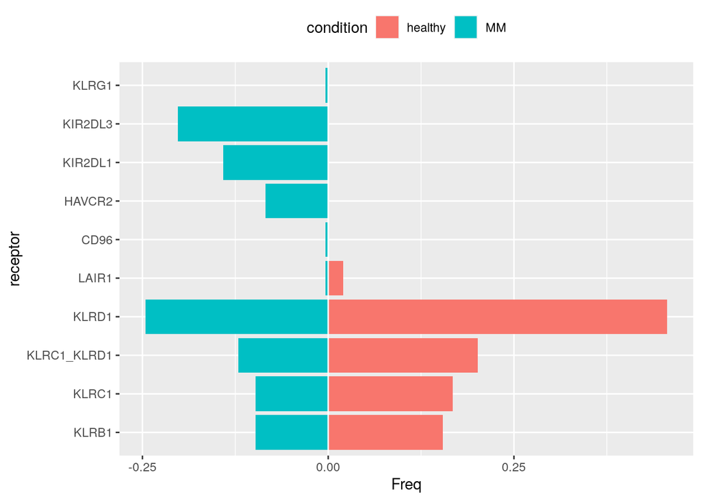

```r
mm_res_ICR <- mm_ICR[mm_ICR$target == "NK resident", ]
ht_res_ICR <- ht_ICR[ht_ICR$target == "NK resident", ]


exh_source <- as.data.frame(table(mm_res_ICR$receptor.complex)/sum(table(mm_res_ICR$receptor.complex))) %>%
  arrange(desc(Freq)) %>%
  rename(receptor = "Var1") %>%
  mutate(condition="MM")
res_source <- as.data.frame(table(ht_res_ICR$receptor.complex)/sum(table(ht_res_ICR$receptor.complex))) %>%
  arrange(desc(Freq)) %>%
  rename(receptor = "Var1") %>%
  mutate(condition="healthy")

source <- rbind(res_source,exh_source)

source_plot <- source %>%
  mutate(
    Freq = ifelse(condition=="MM", Freq*(-1),
                        Freq*1))%>%
    ggplot(aes(x = receptor,y = Freq, fill=condition)) +
    geom_bar(stat = "identity") +
    coord_flip() +
    geom_hline(yintercept = 0, color="white")+

  theme(legend.position = "top")

source_plot
```

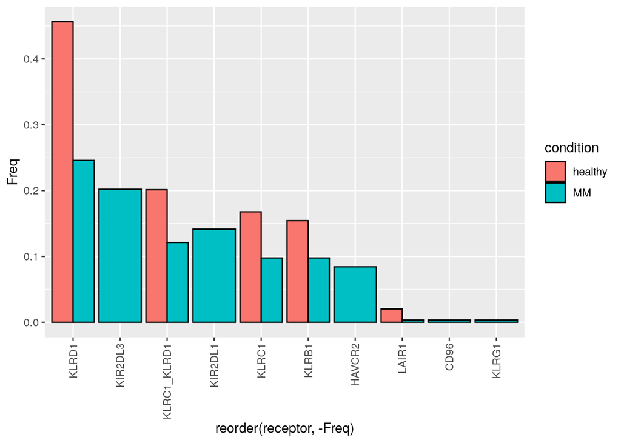

```r
source_dodge <- ggplot(source, aes(x=reorder(receptor,-Freq), y=Freq, fill=condition)) +
geom_bar(stat="identity", color="black", position=position_dodge())+
  theme(axis.text.x = element_text(angle = 90, vjust = 0.5, hjust=1))

source_dodge
```

- KLRG1, KIR2DL3, KIR2DL1, HAVCR2, CD96 active in MM
- LAIR1 more active in healthy than MM samples
- HAVCR2/TIM3 activated only in MM

# Conclusions

- MM samples present higher number of:
  - Interactions
  - Receptors
  - Ligands
- More ICR have been found in MM compared to healthy samples in both:
  - Exhausted NK cells
  - Resident NK cells
- The main ICR activated in healthy cells are KIRs/KLRs and HAVCR2/TIM3, LAIR1
- TIGIT, LAG3, LILRB1, KLRG1, KIR2DL1, CD96/TACTILE are activated only in MM
- Many ICR are activated in resident NK cells from MM while healthy resident NK cell lack this activation

# Next step

Since differences in ICR were found between MM and heathy cells in both exhausted and resident NK cells, I am going to fetch all the ICR ativated in MM in NK cells (exh + res) as starting point to run NicheNet.